```python
from __future__ import annotations

import matplotlib.pyplot as plt
import numpy as np

from example_models import get_linear_chain_2v
from mxlpy import scan, sensitivity
```

# Global sensitivity analysis

Before committing to an expensive analysis — parameter fitting, profile-likelihood identifiability, or a full variance-based Sobol decomposition — it pays to ask a cheaper question first: **which parameters actually move the output at all?**

The **Morris method** answers exactly that. It is an *elementary-effects screening* method: it perturbs one parameter at a time along a handful of random trajectories through parameter space and measures how much the output changes. With only `n_trajectories * (k + 1)` model evaluations (`k` = number of parameters) it sorts parameters into three buckets:

| Reading | Interpretation |
| --- | --- |
| low `mu_star` | unimportant — safe to fix to a constant |
| high `mu_star`, low `sigma` | important and roughly **linear** |
| high `mu_star`, high `sigma` | important and **nonlinear** or interacting |

where `mu_star` is the mean *absolute* elementary effect and `sigma` its standard deviation across trajectories.

## The output function

Sensitivity is always measured with respect to *some scalar output* of the model. Rather than ship a fixed menu of reductions, `sensitivity.morris` asks you for an **output function**:

```
output(model, samples: pd.DataFrame) -> np.ndarray
```

It receives the model and the full matrix of parameter samples (one row per sample, one column per parameter) and returns one scalar per row. The natural way to write it is to lean on `mxlpy.scan`, which already evaluates the whole sample matrix in parallel, caches results, and — importantly — returns `NaN` for any sample whose integration failed. That `NaN` flows straight through to the sensitivity indices, so failed runs surface honestly instead of being silently masked.

Any reduction `scan` can express is available for free:

- **steady-state value** of a species: `scan.steady_state(model, to_scan=samples).variables[name]`
- **peak value** over a time course: `scan.time_course(model, to_scan=samples, time_points=...).get_agg_per_run("max")[name]`
- **area under the curve**: pass `np.trapezoid` as the aggregator to `get_agg_per_run`

Here we screen the steady-state concentration of `x` in a simple linear chain $\varnothing \xrightarrow{v_1} x \xrightarrow{v_2} y \xrightarrow{v_3} \varnothing$ against its three rate constants.

```python
def steady_state_x(model, samples):
    return scan.steady_state(model, to_scan=samples).variables["x"].to_numpy()


result = sensitivity.morris(
    get_linear_chain_2v(),
    output=steady_state_x,
    param_bounds={"k1": (0.5, 2.0), "k2": (0.5, 2.0), "k_out": (0.5, 2.0)},
    n_trajectories=5,
    seed=0,
)
result.sort_values("mu_star", ascending=False)
```

|  | mu | mu_star | sigma | mu_star_conf |
| --- | --- | --- | --- | --- |
| k2 | -2.100000e+00 | 2.100000e+00 | 1.341641e+00 | 1.009701e+00 |
| k1 | 1.900000e+00 | 1.900000e+00 | 1.024695e+00 | 8.569927e-01 |
| k_out | -1.477828e-10 | 1.477953e-10 | 3.304699e-10 | 2.676228e-10 |

The result is a labelled `pandas.DataFrame` indexed by parameter name with columns `mu`, `mu_star`, `sigma`, and `mu_star_conf` (a bootstrap confidence interval on `mu_star`).

The reading is immediate: at steady state $x = k_1 / k_2$, so `k1` and `k2` dominate while `k_out` — which only drains the downstream species `y` — has an elementary effect of essentially zero. A screening run like this lets you drop `k_out` from a subsequent fit without losing anything.

## Visualising the screen

Two plots make the screen easy to read: a ranking of `mu_star` (with its confidence interval), and a `mu_star`-vs-`sigma` scatter that separates linear from nonlinear influence.

```python
ranked = result.sort_values("mu_star")

fig, (ax1, ax2) = plt.subplots(1, 2, figsize=(9, 3.5))

ax1.barh(ranked.index, ranked["mu_star"], xerr=ranked["mu_star_conf"])
ax1.set(xlabel=r"$\mu^*$ (mean absolute effect)", title="Parameter ranking")

ax2.scatter(result["mu_star"], result["sigma"])
for name, row in result.iterrows():
    ax2.annotate(name, (row["mu_star"], row["sigma"]))
ax2.set(xlabel=r"$\mu^*$", ylabel=r"$\sigma$", title="Linear vs. nonlinear")

fig.tight_layout()
plt.show()
```

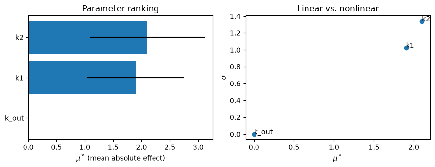

## Cost and reproducibility

Pass a `seed` for reproducible sampling and bootstrap confidence intervals, and tune `num_levels` (default `4`) to control the granularity of the sampling grid.

```python
n_params = 3
n_trajectories = 20
print(f"Evaluations: {n_trajectories * (n_params + 1)}")
```

```
Evaluations: 80
```

## From screening to quantification: Sobol indices

Morris tells you *which* parameters matter; it does not tell you *how much* each one explains, nor cleanly separate a parameter's own effect from the effect of its interactions. The **Sobol method** does both. It is a *variance-based* method: it decomposes the total variance of the output into the share attributable to each parameter.

It returns two indices per parameter:

| Index | Meaning |
| --- | --- |
| `S1` (first-order) | fraction of output variance explained by that parameter **alone** |
| `ST` (total-order) | fraction explained by that parameter **including all of its interactions** |

The gap `ST - S1` is the interaction signal: if it is large, the parameter matters mostly *through* other parameters rather than on its own.

`sobol` takes the **same `output` and `param_bounds` contract as `morris`**, so the reduction you already wrote carries over unchanged. The one new knob is `n_samples` (the Saltelli base sample size), which **must be a power of two** — passing anything else raises a `ValueError`. The total cost is `n_samples * (k + 2)` model evaluations, which is why you screen with Morris first and reserve Sobol for the survivors.

```python
result_sobol = sensitivity.sobol(
    get_linear_chain_2v(),
    output=steady_state_x,
    param_bounds={"k1": (0.5, 2.0), "k2": (0.5, 2.0), "k_out": (0.5, 2.0)},
    n_samples=512,
    seed=0,
)
result_sobol.sort_values("ST", ascending=False)
```

|  | S1 | ST | S1_conf | ST_conf |
| --- | --- | --- | --- | --- |
| k2 | 5.427225e-01 | 6.108146e-01 | 9.897648e-02 | 7.437924e-02 |
| k1 | 3.829592e-01 | 4.491552e-01 | 7.985550e-02 | 7.417732e-02 |
| k_out | -5.538662e-11 | 1.247718e-19 | 4.765769e-11 | 8.604672e-20 |

The result is a labelled `pandas.DataFrame` indexed by parameter name with columns `S1`, `ST`, and their bootstrap confidence intervals `S1_conf`, `ST_conf`.

The story matches the Morris screen but is now quantitative: with $x = k_1 / k_2$ at steady state, `k1` and `k2` carry essentially all of the variance while `k_out` contributes nothing. Here `S1` and `ST` are close for every parameter, telling us the influence is largely additive over this box rather than interaction-driven.

```python
ranked = result_sobol.sort_values("ST")

fig, ax = plt.subplots(figsize=(6, 3.5))
y = np.arange(len(ranked))
ax.barh(
    y - 0.2, ranked["S1"], height=0.4, xerr=ranked["S1_conf"], label="S1 (first-order)"
)
ax.barh(
    y + 0.2, ranked["ST"], height=0.4, xerr=ranked["ST_conf"], label="ST (total-order)"
)
ax.set_yticks(y, ranked.index)
ax.set(xlabel="Sobol index", title="Variance decomposition")
ax.legend()
fig.tight_layout()
plt.show()
```

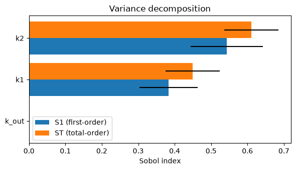

**Screen, then quantify.** Morris is the cheap first pass that discards parameters you can safely fix; Sobol is the more expensive second pass that puts numbers on the ones that survive. Used together they turn a high-dimensional parameter space into a short, ranked list of the parameters worth fitting or measuring.